# Comparative analysis in Seurat v5

Compiled: 2026-11-01

load libraries

```r
library(Seurat)
library(BPCells)
library(tidyverse)
library(harmony)
library(viridisLite)
library(Azimuth)
# needs to be set for large dataset analysis
options(future.globals.maxSize = 1e9)
```

#how to access the data Due to limited time we will not go through the process of downloading the data and creating Seurat object. A lot of publications deposit their data on GEO database where you can often find 3 files stored as supplement: matrix (mtx): counts, gene expression barcodes (tsv): sells features (tsv): genes Look for data availability in the end of the publication.

code example on whre to download the data and how to create Seurat object from it is pastedbelow. We do not need this code for the excercise. It it is pasted here just as modifiable example if you would like to use another data set. This example will work with mapped datasets. If the data is published as raw data (before genome mapping) then you would need to do this step as well.

```r
#https://www.ncbi.nlm.nih.gov/geo/query/acc.cgi?acc=GSM5067109
#expression_matrix <- ReadMtx(mtx = "C:/Users/Kaja Moczulska/Downloads/GSM5067109_EKO_matrix.mtx.gz",
#                             cells = "C:/Users/Kaja Moczulska/Downloads/GSM5067109_EKO_barcodes.tsv.gz",
#                             features = "C:/Users/Kaja Moczulska/Downloads/GSM5067109_EKO_genes.tsv.gz")
#Seurat_AD <- CreateSeuratObject(expression_matrix)
#saveRDS(
#  object = Seurat_AD,
#  file = "Eko_hippo.rds")
#
#rm(expression_matrix)
```

# Standard pre-processing workflow

The steps below encompass the standard pre-processing workflow for scRNA-seq data in Seurat. These represent the selection and filtration of cells based on QC metrics, data normalization and scaling, and the detection of highly variable features.

## QC and selecting cells for further analysis

Seurat allows you to easily explore QC metrics and filter cells based on any user-defined criteria. A few QC metrics [commonly used](https://www.ncbi.nlm.nih.gov/pmc/articles/PMC4758103/) by the community include

- The number of unique genes detected in each cell.
  - Low-quality cells or empty droplets will often have very few genes
  - Cell doublets or multiplets may exhibit an aberrantly high gene count
- Similarly, the total number of molecules detected within a cell (correlates strongly with unique genes)
- The percentage of reads that map to the mitochondrial genome
  - Low-quality / dying cells often exhibit extensive mitochondrial contamination
  - We calculate mitochondrial QC metrics with the `PercentageFeatureSet()` function, which calculates the percentage of counts originating from a set of features
  - We use the set of all genes starting with `MT-` as a set of mitochondrial genes

nFeatures: number of unique genes detected in a cell nCount: total number of RNA molecules detected in that same cell

```r
#load datasets
#setwd("~/data")
Seurat_AD <- LoadSeuratRds('./Input_data/Eko_hippo.rds')
Seurat_WT <- LoadSeuratRds('./Input_data/WT_hippo.rds')
condition <- vector(mode="character", length=length(Seurat_AD$orig.ident))
condition [1:length(condition)] <- "AD"
Seurat_AD <- AddMetaData(object = Seurat_AD, metadata = condition, col.name = "condition")

condition <- vector(mode="character", length=length(Seurat_WT$orig.ident))
condition [1:length(condition)] <- "WT"
Seurat_WT <- AddMetaData(object = Seurat_WT, metadata = condition, col.name = "condition")

rm(condition)
```

```r
# The [[ operator can add columns to object metadata. This is a great place to stash QC stats
Seurat_WT[["percent.mt"]] <- PercentageFeatureSet(Seurat_WT, pattern = "^mt-")
```

**Where are QC metrics stored in Seurat?**

- The number of unique genes and total molecules are automatically calculated during `CreateSeuratObject()`
  - You can find them stored in the object meta data

```r
# Show QC metrics for the first 5 cells
head(Seurat_WT@meta.data, 5)
```

|  | orig.ident | nCount_RNA | nFeature_RNA | condition | percent.mt |
| --- | --- | --- | --- | --- | --- |
| AAACCTGAGACCACGA-1 | SeuratProject | 1476 | 864 | WT | 1.4905149 |
| AAACCTGAGAGTAATC-1 | SeuratProject | 1637 | 799 | WT | 1.4050092 |
| AAACCTGAGATGTCGG-1 | SeuratProject | 2384 | 1203 | WT | 24.1610738 |
| AAACCTGAGCGACGTA-1 | SeuratProject | 1934 | 1053 | WT | 0.9824199 |
| AAACCTGAGGACGAAA-1 | SeuratProject | 2107 | 1154 | WT | 1.0441386 |

In the example below, we visualize QC metrics, taht we will use to filter out cells.

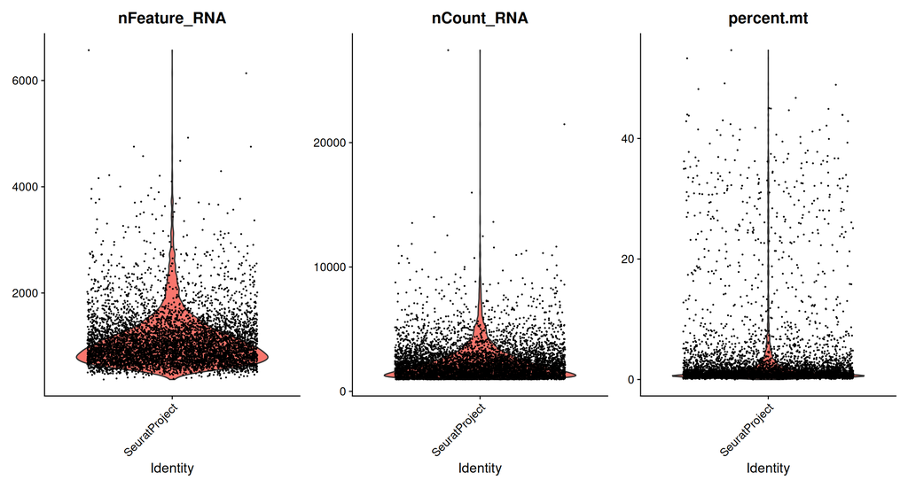

```r
#Visualize QC metrics as a violin plot
VlnPlot(Seurat_WT, features = c("nFeature_RNA", "nCount_RNA", "percent.mt"), ncol = 3)
```

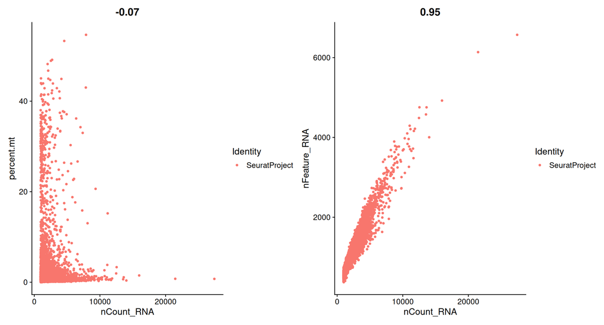

```r
# FeatureScatter is typically used to visualize feature-feature relationships, but can be used for anything calculated by the object, i.e. columns in object metadata, PC scores etc.

plot1 <- FeatureScatter(Seurat_WT, feature1 = "nCount_RNA", feature2 = "percent.mt")
plot2 <- FeatureScatter(Seurat_WT, feature1 = "nCount_RNA", feature2 = "nFeature_RNA")
plot1 + plot2
```

## Filter out the bad quality cells

```r
Seurat_WT <- subset(Seurat_WT, subset = nFeature_RNA < 2500 & percent.mt < 5)
```

# Normalizing the data

After removing unwanted cells from the dataset, the next step is to normalize the data. By default, we employ a global-scaling normalization method “LogNormalize” that normalizes the feature expression measurements for each cell by the total expression, multiplies this by a scale factor (10,000 by default), and log-transforms the result. In Seurat v5, Normalized values are stored in `obj[["RNA"]]$data`.

```r
#Seurat_WT <- NormalizeData(Seurat_WT, normalization.method = "LogNormalize", scale.factor = 1e4)
```

For clarity, in this previous line of code (and in future commands), we provide the default values for certain parameters in the function call. However, this isn’t required and the same behavior can be achieved with:

```r
Seurat_WT <- NormalizeData(Seurat_WT)
```

```
## Normalizing layer: counts
```

```r
Seurat_WT
```

```
## An object of class Seurat
## 27998 features across 5363 samples within 1 assay
## Active assay: RNA (27998 features, 0 variable features)
##  2 layers present: counts, data
```

While this method of normalization is standard and widely used in scRNA-seq analysis, global-scaling relies on an assumption that each cell originally contains the same number of RNA molecules. We and others have developed alternative workflows for the single cell preprocessing that do not make these assumptions. For users who are interested, please check out our `SCTransform()` normalization workflow. The method is described in our[paper](https://genomebiology.biomedcentral.com/articles/10.1186/s13059-021-02584-9), with a separate vignette using Seurat [here](https://satijalab.org/seurat/articles/sctransform_vignette.html). The use of `SCTransform` replaces the need to run `NormalizeData`, `FindVariableFeatures`, or `ScaleData` (described below.)

## Compare Normalization with Counts

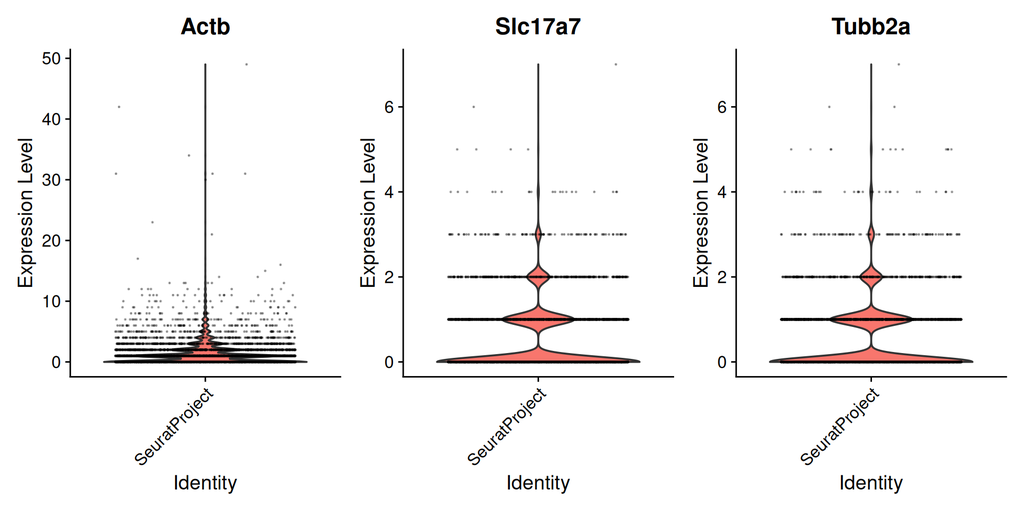

```r
VlnPlot(Seurat_WT, features = c("Actb", "Slc17a7", "Tubb2a"), ncol = 3, layer = "counts", alpha = 0.3)
```

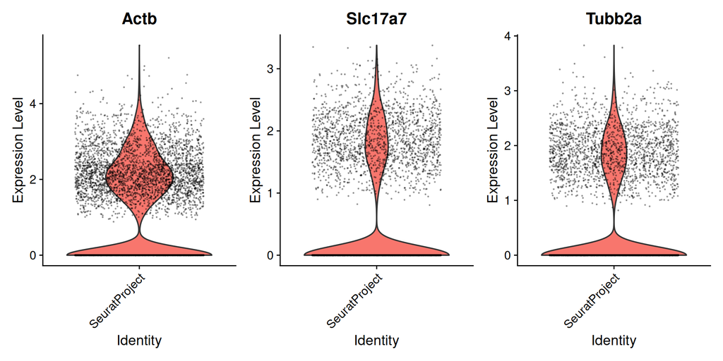

```r
# We then visualize normalized data
VlnPlot(Seurat_WT, features = c("Actb", "Slc17a7", "Tubb2a"), ncol = 3, layer = "data", alpha = 0.3)
```

Now our data is cleaned and normalised and ready to compare with the second dataset (in our case with data from AD mice). However, we need to preprocess the other dataset as well.

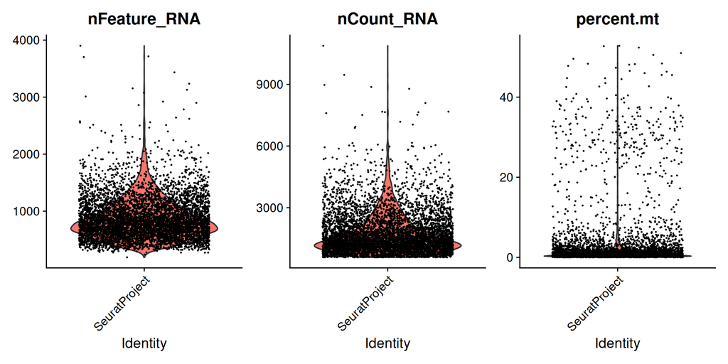

```r
# The [[ operator can add columns to object metadata. This is a great place to stash QC stats
Seurat_AD[["percent.mt"]] <- PercentageFeatureSet(Seurat_AD, pattern = "^mt-")

#Visualize QC metrics as a violin plot
VlnPlot(Seurat_AD, features = c("nFeature_RNA", "nCount_RNA", "percent.mt"), ncol = 3)
```

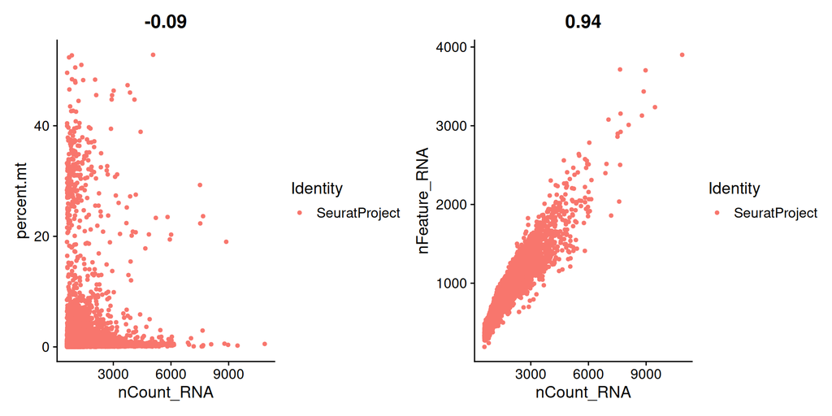

```r
# FeatureScatter is typically used to visualize feature-feature relationships, but can be used for anything calculated by the object, i.e. columns in object metadata, PC scores etc.

plot1 <- FeatureScatter(Seurat_AD, feature1 = "nCount_RNA", feature2 = "percent.mt")
plot2 <- FeatureScatter(Seurat_AD, feature1 = "nCount_RNA", feature2 = "nFeature_RNA")
plot1 + plot2
```

Are our filter cut offs (pre-filled below) good for the second data set?

```r
Seurat_AD <- subset(Seurat_AD, subset = nFeature_RNA < 2500  & percent.mt < 5)
```

And normalise second dataset:

```r
Seurat_AD <- NormalizeData(Seurat_AD)
```

```
## Normalizing layer: counts
```

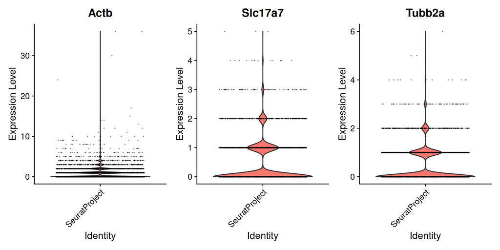

```r
VlnPlot(Seurat_AD, features = c("Actb", "Slc17a7", "Tubb2a"), ncol = 3, layer = "counts", alpha = 0.3)
```

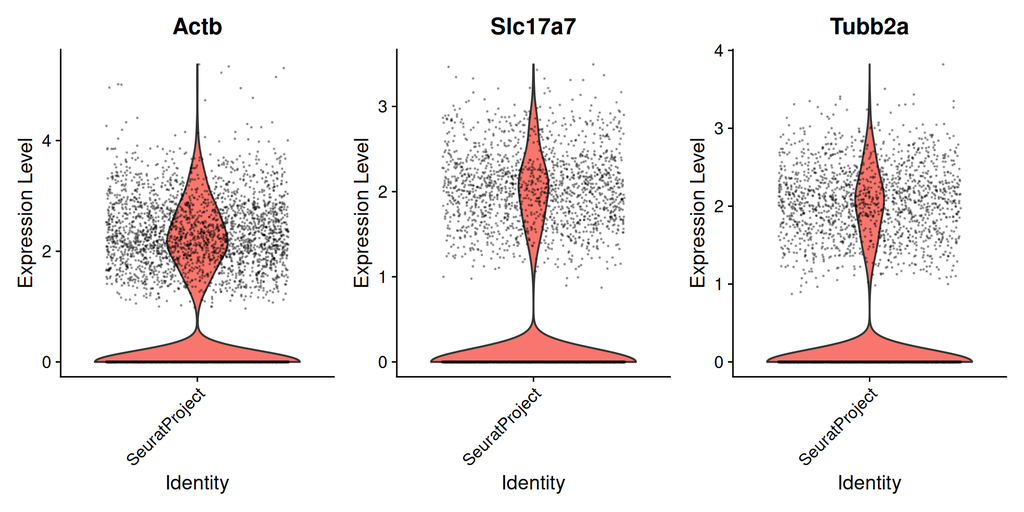

```r
# We then visualize normalized data
VlnPlot(Seurat_AD, features = c("Actb", "Slc17a7", "Tubb2a"), ncol = 3, layer = "data", alpha = 0.3)
```

Now let’s have a look at object info for both data sets:

```r
Seurat_WT
```

```
## An object of class Seurat
## 27998 features across 5363 samples within 1 assay
## Active assay: RNA (27998 features, 0 variable features)
##  2 layers present: counts, data
```

```r
Seurat_AD
```

```
## An object of class Seurat
## 27998 features across 5446 samples within 1 assay
## Active assay: RNA (27998 features, 0 variable features)
##  2 layers present: counts, data
```

# Intro: Looking at data in Seurat v5

We will first look at variable genes in our data, to identify which genes could potentially play a role to distinguish cell types. ## Identification of highly variable features (feature selection) We calculate a subset of features that exhibit high cell-to-cell variation in the dataset (i.e, they are highly expressed in some cells, and lowly expressed in others). We and [others](https://www.nature.com/articles/nmeth.2645) have found that focusing on these genes in downstream analysis helps to highlight biological signal in single-cell datasets.

Our procedure in Seurat is described in detail [here](https://doi.org/10.1016/j.cell.2019.05.031), and improves on previous versions by directly modeling the mean-variance relationship inherent in single-cell data, and is implemented in the `FindVariableFeatures()` function. By default, we return 2,000 features per dataset. These will be used in downstream analysis, like PCA.

```r
Seurat_WT <- FindVariableFeatures(Seurat_WT)
```

```
## Finding variable features for layer counts
```

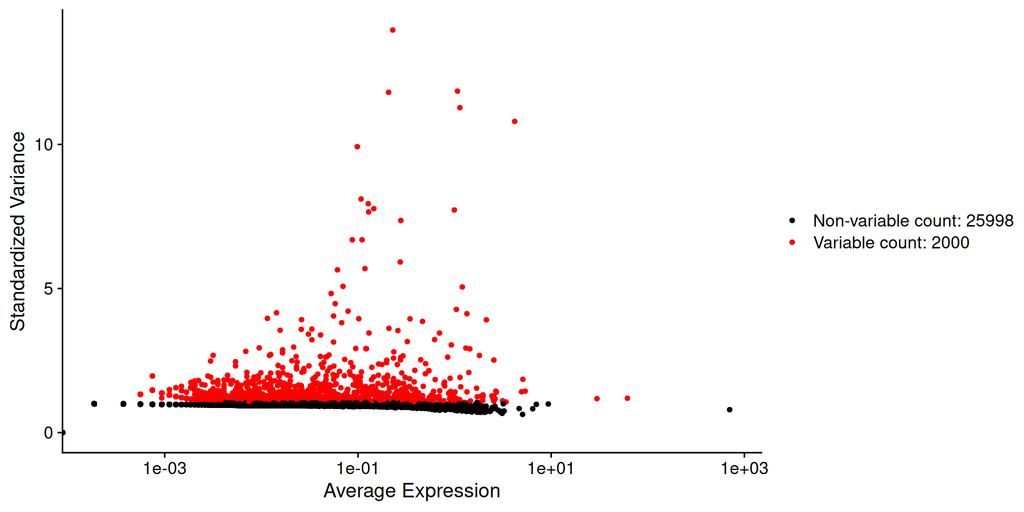

```r
# plot variable features with and without labels
 VariableFeaturePlot(Seurat_WT)
```

```r
# Identify the 20 most highly variable genes
top20 <- head(VariableFeatures(Seurat_WT), 20)

# plot variable features with and without labels
plot1 <- VariableFeaturePlot(Seurat_WT)
plot2 <- LabelPoints(plot = plot1, points = top20, repel = TRUE)
```

```
## When using repel, set xnudge and ynudge to 0 for optimal results
```

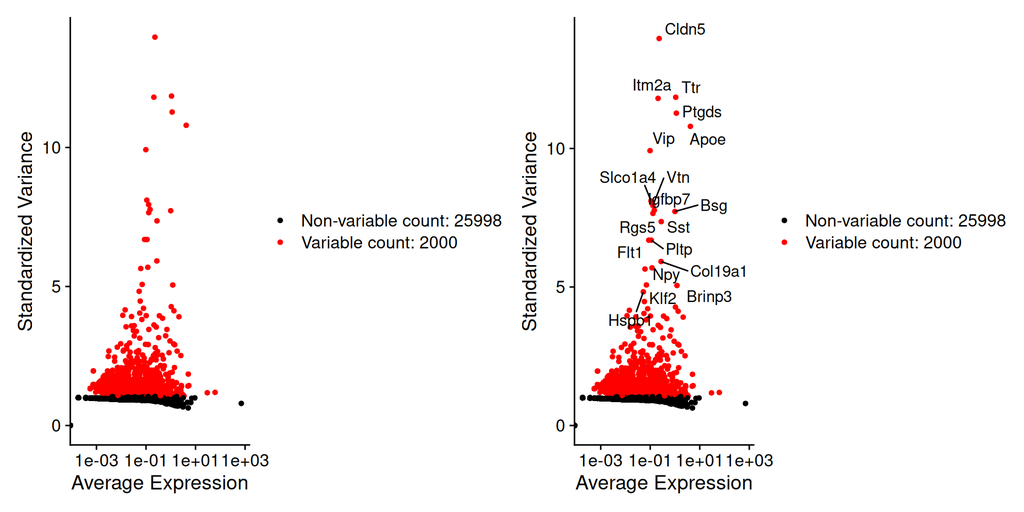

```r
plot1 + plot2
```

## Scaling the data

```r
Seurat_WT <- ScaleData(Seurat_WT)
```

## Perform linear dimensional reduction

Next we perform PCA on the scaled data. By default, only the previously determined variable features are used as input, but can be defined using `features` argument if you wish to choose a different subset (if you do want to use a custom subset of features, make sure you pass these to `ScaleData` first).

For the first principal components, Seurat outputs a list of genes with the most positive and negative loadings, representing modules of genes that exhibit either correlation (or anti-correlation) across single-cells in the dataset.

```r
Seurat_WT <- RunPCA(Seurat_WT, features = VariableFeatures(object = Seurat_WT), npcs = 25)
```

```
## PC_ 1
## Positive:  Meg3, Snhg11, Opcml, Pcsk2, Tenm2, Epha5, Grin2a, R3hdm1, Rnf112, Fam19a1
##     Chrm3, Atp2b1, 9530059O14Rik, PISD, Csmd2, Pex5l, Lrtm1, Cpne7, Rgs11, 5330434G04Rik
##     Zeb2, Chrd, Khdrbs2, Epha7, Nrxn3, Stxbp5l, Lrp1b, Lingo2, 3110035E14Rik, Chgb
## Negative:  Flt1, Hspb1, Cldn5, Slco1a4, Klf2, Pltp, Ly6c1, Rgs5, Igfbp7, Id1
##     Ly6a, Itm2a, Esam, Lsr, Abcb1a, Cxcl12, Epas1, Eng, Ifitm3, Emcn
##     Tm4sf1, Slco1c1, Acvrl1, Ctla2a, Adgrl4, Nfkbia, Ahnak, Id3, Myl12a, Fcgrt
## PC_ 2
## Positive:  Meg3, Snhg11, Flt1, Opcml, Hspb1, Slco1a4, Cldn5, Lsr, Klf2, Emcn
##     Rgs5, Pcsk2, Ly6c1, Esam, Ly6a, Acvrl1, Ctla2a, Eng, Tenm2, Itm2a
##     Pglyrp1, Adgrl4, Abcb1a, Cxcl12, Igfbp7, Sox18, Pltp, Gm694, Ly6e, Podxl
## Negative:  Plpp3, Gpr37l1, Slc1a3, Gja1, Atp1a2, F3, Apoe, Pla2g7, Clu, Ntsr2
##     Htra1, Mfge8, Slc7a10, Slc1a2, Ndrg2, Mlc1, Aqp4, Pax6, Mt2, Cst3
##     Btbd17, Aldoc, Cldn10, Tril, Pbxip1, Id4, Rorb, Phkg1, Bcan, Mt1
## PC_ 3
## Positive:  Fam19a1, Zbtb20, Atp2b1, Rnf112, Grin2a, Gm44257, 4921539H07Rik, Chrd, Rnf182, Wipf3
##     Epha4, Cpne7, Pkp2, Wbscr17, Epha7, Hpca, Rasgrp1, Neurod6, Fibcd1, Plk2
##     Pantr1, Ntsr2, Pex5l, Neurod2, Wfs1, 3110035E14Rik, Zeb2, Chrm3, 9530059O14Rik, Cul4a
## Negative:  Cit, Maf, Slc32a1, Col19a1, Coro6, Nxph1, Slc6a1, Cacna2d2, Ankrd24, Mef2c
##     Kcnc1, Lrrtm3, Gad1, Tmem145, Gm13629, Snhg11, Gad2, Sst, Dlx6os1, Usp29
##     Zfp536, Vwa5b2, C1qa, Cntnap4, Sgcz, Hexb, C1qc, Csf1r, Camk1, Brinp3
## PC_ 4
## Positive:  Snhg11, Cit, Coro6, Ntm, Slc32a1, Col19a1, Meg3, Maf, Ankrd24, Tle2
##     Sgcz, Vwa5b2, Npas1, Nxph1, Mir124-2hg, Tshz2, Cacna2d2, Dlx6os1, Rmst, Gad2
##     Gpc6, Brinp3, Elavl2, Ache, Elfn1, Slc6a1, Gm13629, Sst, Kcnc1, Serpini1
## Negative:  C1qa, Csf1r, C1qc, Selplg, Trf, Ctss, C1qb, Hexb, Plp1, Trem2
##     Mag, Olfml3, P2ry12, Laptm5, Zbtb20, Tmem119, Gpr34, Adap2os, Vsir, Neat1
##     Cx3cr1, Fcrls, Tgfbr1, C1ql3, Cldn11, Unc93b1, Fam19a1, Apod, Hk2, Hapln2
## PC_ 5
## Positive:  Snhg11, Chrm3, Meg3, Cpne7, Pex5l, Ntm, Cpe, 3110035E14Rik, Sv2b, Rgs11
##     Pid1, Epha5, Kcnn2, 9530059O14Rik, Col11a1, Man1a, Sez6, Cul4a, Akap13, Plk2
##     5031439G07Rik, Lrtm1, Mgat4c, Neurod6, Rasgrp1, R3hdm1, Dkk3, Fezf2, Runx1t1, Pantr1
## Negative:  C1ql2, C1ql3, Synpr, Plk5, Tmem108, Dock10, Cntnap5a, Cald1, Prdm5, Onecut1
##     Lingo2, Ahcyl2, Lrrtm4, Rfx3, Ntng1, Negr1, Thsd7a, Pcdh8, Crlf1, Sema5a
##     Rasl10a, Tiam1, Jun, Prox1, Mef2c, Il1rap, Stxbp6, Gm12216, Pdzd2, Phxr4
```

Seurat provides several useful ways of visualizing both cells and features that define the PCA, including `VizDimReduction()`, `DimPlot()`, and `DimHeatmap()`

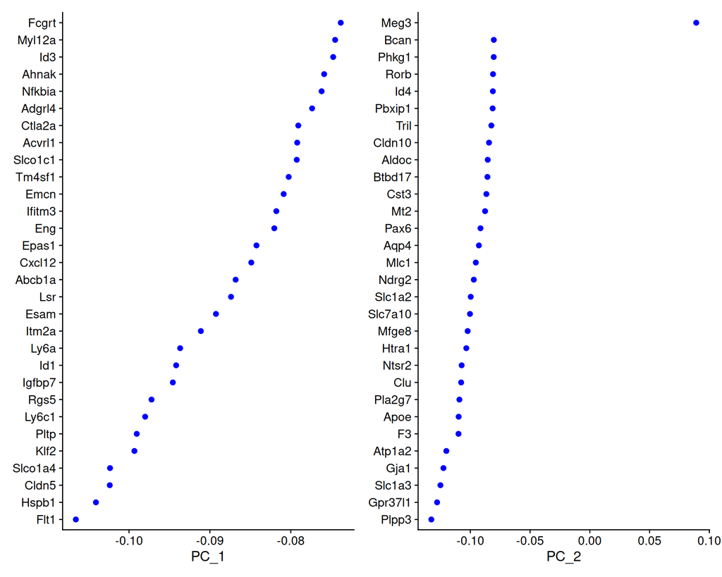

```r
# Examine and visualize PCA results a few different ways
VizDimLoadings(Seurat_WT, dims = 1:2, reduction = 'pca')
```

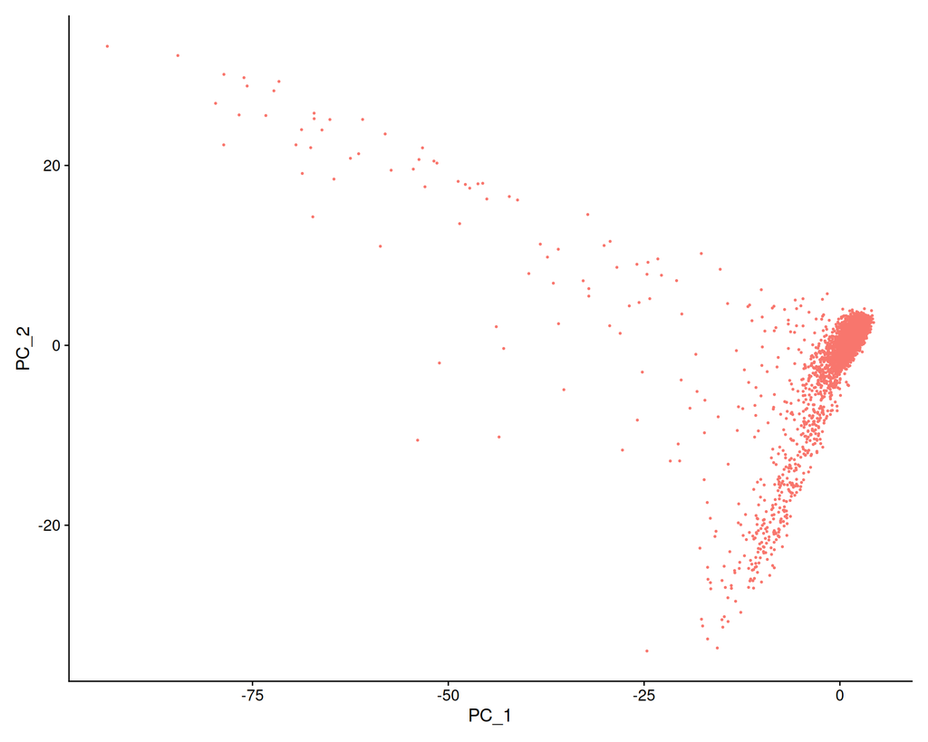

```r
DimPlot(Seurat_WT, reduction = 'pca') + NoLegend()
```

In particular `DimHeatmap()` allows for easy exploration of the primary sources of heterogeneity in a dataset, and can be useful when trying to decide which PCs to include for further downstream analyses. Both cells and features are ordered according to their PCA scores. Setting `cells` to a number plots the ‘extreme’ cells on both ends of the spectrum, which dramatically speeds plotting for large datasets. Though clearly a supervised analysis, we find this to be a valuable tool for exploring correlated feature sets.

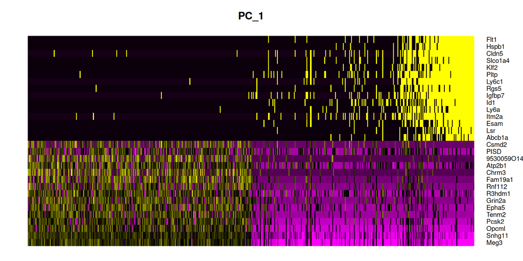

```r
DimHeatmap(Seurat_WT, dims = 1, cells = 500, balanced = TRUE)
```

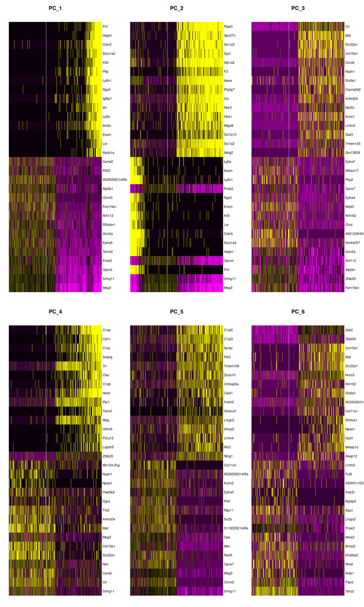

```r
DimHeatmap(Seurat_WT, dims = 1:6, cells = 500, balanced = TRUE)
```

## Determine the ‘dimensionality’ of the dataset

To overcome the extensive technical noise in any single feature for scRNA-seq data, Seurat clusters cells based on their PCA scores, with each PC essentially representing a ‘metafeature’ that combines information across a correlated feature set. The top principal components therefore represent a robust compression of the dataset. However, how many components should we choose to include? 10? 20? 100?

In Macosko *et al*, a resampling test was implemented inspired by the JackStraw procedure. While still available in Seurat [(see previous vignette)](https://satijalab.org/seurat/articles/pbmc3k_tutorial), this is a slow and computationally expensive procedure, and we is no longer routinely used in single cell analysis.

An alternative heuristic method generates an ‘Elbow plot’: a ranking of principle components based on the percentage of variance explained by each one (`ElbowPlot()` function). In this example, we can observe an ‘elbow’ around PC9-10, suggesting that the majority of true signal is captured in the first 10 PCs.

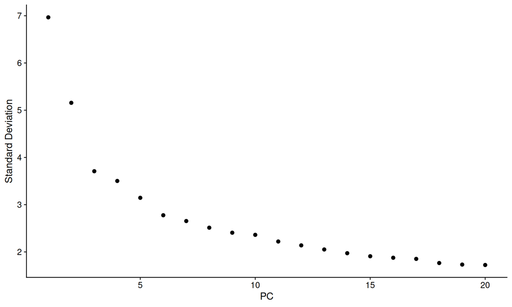

```r
ElbowPlot(Seurat_WT)
```

Identifying the true dimensionality of a dataset – can be challenging/uncertain for the user. We therefore suggest these multiple approaches for users. The first is more supervised, exploring PCs to determine relevant sources of heterogeneity, and could be used in conjunction with GSEA for example. The second (`ElbowPlot`) The third is a heuristic that is commonly used, and can be calculated instantly. In this example, we might have been justified in choosing anything between PC 7-12 as a cutoff.

# Cluster the cells

Seurat applies a graph-based clustering approach, building upon initial strategies in (Macosko *et al*). Importantly, the *distance metric* which drives the clustering analysis (based on previously identified PCs) remains the same. However, our approach to partitioning the cellular distance matrix into clusters has dramatically improved. Our approach was heavily inspired by recent manuscripts which applied graph-based clustering approaches to scRNA-seq data [[SNN-Cliq, Xu and Su, Bioinformatics, 2015]](http://bioinformatics.oxfordjournals.org/content/early/2015/02/10/bioinformatics.btv088.abstract) and CyTOF data [[PhenoGraph, Levine *et al*., Cell, 2015]](http://www.ncbi.nlm.nih.gov/pubmed/26095251). Briefly, these methods embed cells in a graph structure - for example a K-nearest neighbor (KNN) graph, with edges drawn between cells with similar feature expression patterns, and then attempt to partition this graph into highly interconnected ‘quasi-cliques’ or ‘communities’.

To cluster the cells, we next apply modularity optimization techniques such as the Louvain algorithm (default) or SLM [[SLM, Blondel *et al*., Journal of Statistical Mechanics]](http://dx.doi.org/10.1088/1742-5468/2008/10/P10008), to iteratively group cells together, with the goal of optimizing the standard modularity function. The `FindClusters()` function implements this procedure, and contains a resolution parameter that sets the ‘granularity’ of the downstream clustering, with increased values leading to a greater number of clusters. We find that setting this parameter between 0.4-1.2 typically returns good results for single-cell datasets of around 3K cells. Optimal resolution often increases for larger datasets. The clusters can be found using the `Idents()` function.

```r
Seurat_WT <- FindNeighbors(Seurat_WT,reduction = "pca", dims = 1:13)
Seurat_WT <- FindClusters(Seurat_WT, resolution = 2) # the higher the number the higher the clusters
```

```
## Modularity Optimizer version 1.3.0 by Ludo Waltman and Nees Jan van Eck
##
## Number of nodes: 5363
## Number of edges: 188044
##
## Running Louvain algorithm...
## Maximum modularity in 10 random starts: 0.7580
## Number of communities: 23
## Elapsed time: 0 seconds
```

```r
# Look at cluster IDs of the first 5 cells
head(Idents(Seurat_WT), 5)
```

```
## AAACCTGAGACCACGA-1 AAACCTGAGAGTAATC-1 AAACCTGAGCGACGTA-1 AAACCTGAGGACGAAA-1
##                 12                 12                  4                 16
## AAACCTGAGTACCGGA-1
##                  0
## Levels: 0 1 2 3 4 5 6 7 8 9 10 11 12 13 14 15 16 17 18 19 20 21 22
```

## Run non-linear dimensional reduction (UMAP/tSNE)

Seurat offers several non-linear dimensional reduction techniques, such as tSNE and UMAP, to visualize and explore these datasets. The goal of these algorithms is to learn underlying structure in the dataset, in order to place similar cells together in low-dimensional space. Therefore, cells that are grouped together within graph-based clusters determined above should co-localize on these dimension reduction plots.

While we and others have routinely found 2D visualization techniques like tSNE and UMAP to be valuable tools for exploring datasets, all visualization techniques have limitations, and cannot fully represent the complexity of the underlying data. In particular, these methods aim to preserve local distances in the dataset (i.e. ensuring that cells with very similar gene expression profiles co-localize), but often do not preserve more global relationships. We encourage users to leverage techniques like UMAP for visualization, but to avoid drawing biological conclusions solely on the basis of visualization techniques.

```r
Seurat_WT <- RunUMAP(Seurat_WT, dims = 1:13)
```

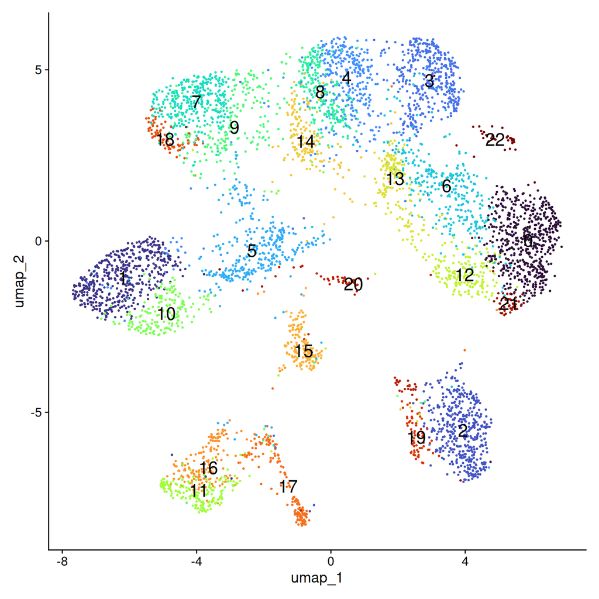

```r
N_clusters <-length(unique(Idents(Seurat_WT)))
# note that you can set `label = TRUE` or use the LabelClusters function to help label individual clusters
plot1 <- DimPlot(Seurat_WT, label = T, label.size = 6, reduction = 'umap', cols = turbo(N_clusters)) + NoLegend()
plot1
```

## Practical

Find the pca components that you think give you reliable clusters. Use harmony integration and compare unintegrated, cca and harmony integrated data.

Questions: 1. How to filter the data to get rid of a dying cells b dublets

2. Data integration is needed to avoid cells clustering according to the batch instead of the cell type. Think of an example of a dataset where data integration is especially important.

# Expression analysis ———————————————————————————————————————————————-

Let’s have a look at https://satijalab.org/seurat/articles/integration_introduction#identify-differential-expressed-genes-across-conditions for cell markers etc. See also: https://azimuth.hubmapconsortium.org/references/mouse_motorcortex/

## Look at Features

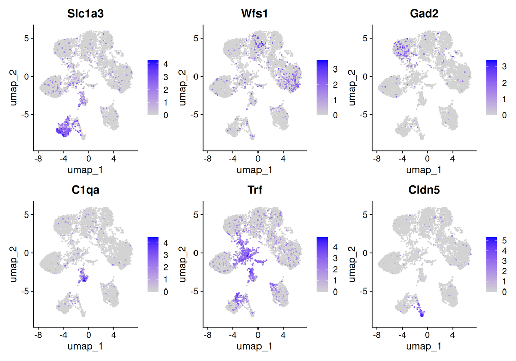

```r
FeaturePlot(
  object = Seurat_WT,
  features = c(
    "Slc1a3", #Astrocytes
    "Wfs1", # Glut Neurons or Slc17a7
    "Gad2", # GABA neurons
    "C1qa", # Microglia
    "Trf", # Myelin-forming mature oligodendrocytes
    "Cldn5"), # Endothelial cells
  ncol = 3)
```

## Differential gene expression

Let’s llok at some genes across: - clusters - conditions (WT vs AD)

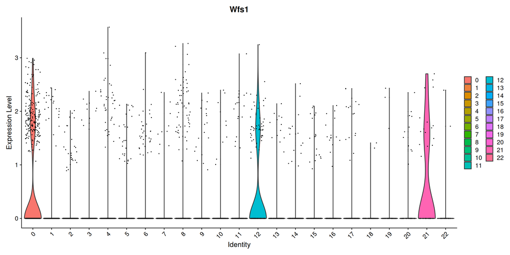

```r
VlnPlot(Seurat_WT, 'Wfs1')
```

This is to just prepare some marker genes Data taken from the publication

```r
# Cluster 0: Wfs1+,Dcn+,Rxfp1- CA1 pyramidal neurons (Excitatory neuron 1)
cluster0 <- c("Wfs1", "Dcn")

# Cluster 1: C1ql2+ Granule cell of the dentate gyrus (Excitatory neuron 2)
cluster1 <- c("C1ql2")

# Cluster 2: Wfs1+,Dcn-,Rxfp1+ CA1 pyramidal neurons (Excitatory neuron 3)
cluster2 <- c("Wfs1", "Rxfp1")

# Cluster 3: Bok+ CA3 pyramidal neurons (Excitatory neuron 4)
cluster3 <- c("Bok")

# Cluster 4: Wfs1-,Dcn-, pyramidal neurons (Excitatory neuron 5)
cluster4 <- c()  # no positive markers

# Cluster 5: Sst+,Erbb4+ CA1 basket cells (Inhibitory neuron 1)
cluster5 <- c("Sst", "Erbb4")

# Cluster 6: Slc1a3+ Astrocytes
cluster6 <- c("Slc1a3")

# Cluster 7: Trf+ Myelin-forming mature oligodendrocytes (MFOLs)
cluster7 <- c("Trf")

# Cluster 8: Vip+,Reln+,Htr3a+,Erbb4+ CA1 basket cells (Inhibitory neuron 2)
cluster8 <- c("Vip", "Reln", "Htr3a", "Erbb4")

# Cluster 9: Ndst4+,Rxfp1+,Dcn- CA1 pyramidal neurons (Excitatory neuron 6)
cluster9 <- c("Ndst4", "Rxfp1")

# Cluster 10: C1qa+,Trf+ Microglia
cluster10 <- c("C1qa", "Trf")

# Cluster 11: Cldn5+ Endothelial cells
cluster11 <- c("Cldn5")

# Cluster 12: Htr2c+,Glra1-  CA1 pyramidal cells (Excitatory neuron 7)
cluster12 <- c("Htr2c")

# Cluster 13: Htr2c+,Glra1+ CA1 pyramidal cells (Inhibitory neuron 3)
cluster13 <- c("Htr2c", "Glra1")

# Cluster 14: Amigo2+ CA2 pyramidal neurons (Excitatory neuron 8)
cluster14 <- c("Amigo2")

# Cluster 15: Pdgfra+ Oligodendrocyte precursor cells (OPCs)
cluster15 <- c("Pdgfra")

# Cluster 16: Reln+,Dcn+ CA1 pyramidal cells (Excitatory neuron 9)
cluster16 <- c("Reln", "Dcn")

# Combine all cluster vectors into one
all_genes <- c(
  cluster0, cluster1, cluster2, cluster3, cluster4, cluster5, cluster6,
  cluster7, cluster8, cluster9, cluster10, cluster11, cluster12, cluster13,
  cluster14, cluster15, cluster16
)

# Remove duplicates
all_genes <- unique(all_genes)
```

## Finding differentially expressed features (cluster biomarkers)

Seurat can help you find markers that define clusters via differential expression (DE). By default, it identifies positive and negative markers of a single cluster (specified in ident.1), compared to all other cells. F FindAllMarkers() automates this process for all clusters, but you can also test groups of clusters vs. each other, or against all cells.

The results data frame has the following columns : p_val : p-value (unadjusted) avg_log2FC : log fold-change of the average expression between the two groups. Positive values indicate that the feature is more highly expressed in the first group. pct.1 : The percentage of cells where the feature is detected in the first group pct.2 : The percentage of cells where the feature is detected in the second group p_val_adj : Adjusted p-value, based on Bonferroni correction using all features in the dataset. If the ident.2 parameter is omitted or set to NULL, FindMarkers() will test for differentially expressed features between the group specified by ident.1 and all other cells. Additionally, the parameter only.pos can be set to TRUE to only search for positive markers, i.e. features that are more highly expressed in the ident.1 group.

In Seurat v5, we use the presto package (as described here and available for installation here), to dramatically improve the speed of DE analysis, particularly for large datasets. For users who are not using presto, you can examine the documentation for this function (?FindMarkers) to explore the min.pct and logfc.threshold parameters, which can be increased in order to increase the speed of DE testing.

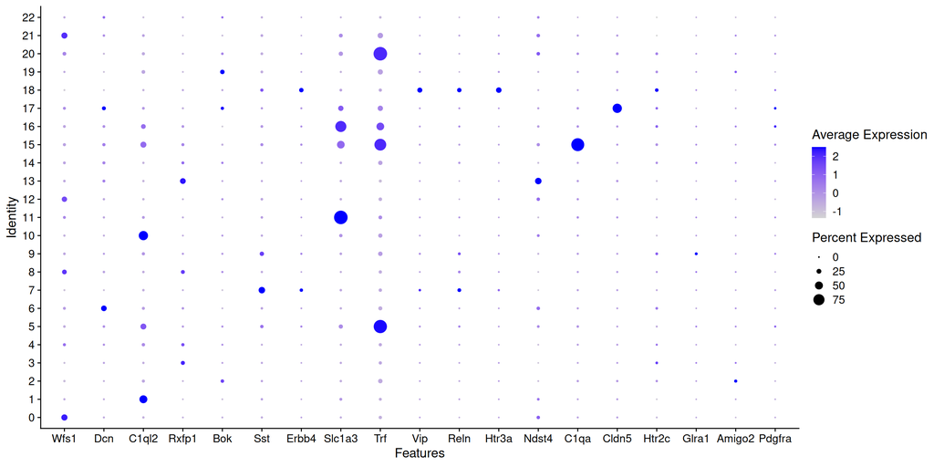

```r
DotPlot(Seurat_WT, features= all_genes)
```

```r
# find all markers of cluster 5
Idents(Seurat_WT) <- "seurat_clusters"
cluster13.markers <- FindMarkers(Seurat_WT, ident.1 = "13", only.pos = TRUE)
head(cluster13.markers, n = 10)
```

|  | p_val | avg_log2FC | pct.1 | pct.2 | p_val_adj |
| --- | --- | --- | --- | --- | --- |
| Etv1 | 0 | 2.708163 | 0.700 | 0.149 | 0 |
| Fn1 | 0 | 3.099718 | 0.359 | 0.041 | 0 |
| Fezf2 | 0 | 2.595461 | 0.559 | 0.121 | 0 |
| Nts | 0 | 3.202487 | 0.206 | 0.017 | 0 |
| Ndst4 | 0 | 2.587034 | 0.382 | 0.065 | 0 |
| Ntng1 | 0 | 1.218172 | 0.929 | 0.416 | 0 |
| Nlrp10 | 0 | 5.231571 | 0.071 | 0.002 | 0 |
| Brinp3 | 0 | 2.417080 | 0.700 | 0.295 | 0 |
| Pex5l | 0 | 1.494662 | 0.871 | 0.436 | 0 |
| Rxfp1 | 0 | 2.164109 | 0.324 | 0.060 | 0 |

### Plot the markers

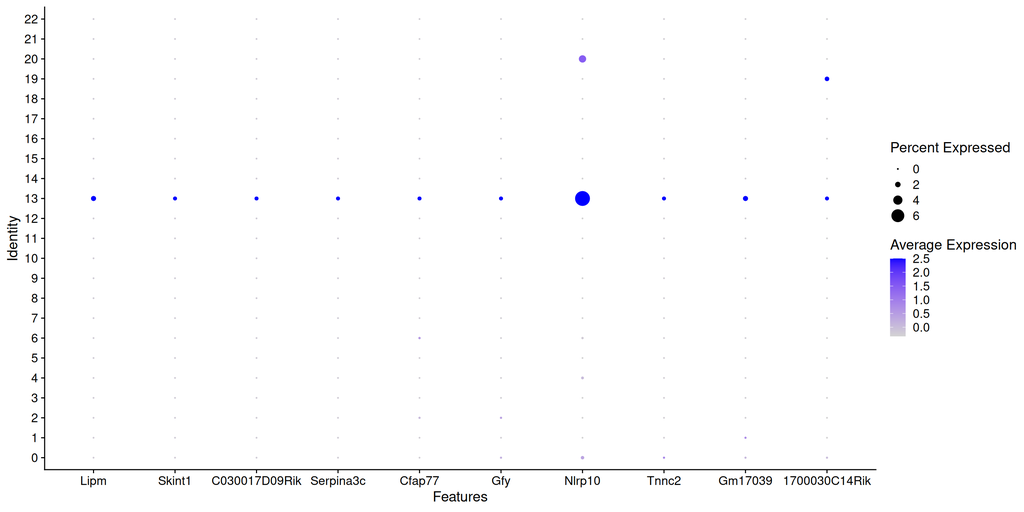

```r
cluster13.markers %>%
    dplyr::filter(avg_log2FC > 2 & p_val < 0.05) %>%
    slice_max(avg_log2FC, n = 10) -> top10

Idents(Seurat_WT) <- "seurat_clusters"
DotPlot(Seurat_WT, features = rownames(top10))
```